# Telecom_project

```python
import pandas as pd
import numpy as np
import matplotlib.pyplot as plt
import seaborn as sns
from IPython.display import display

from sklearn.impute import SimpleImputer, KNNImputer
from sklearn.model_selection import train_test_split, GridSearchCV
from sklearn.metrics import accuracy_score, roc_auc_score, f1_score
from sklearn.ensemble import RandomForestClassifier
from sklearn.linear_model import LogisticRegression
from sklearn.utils import shuffle

import lightgbm as lgb
from catboost import CatBoostClassifier
```

## Exploración de datos

```python
# Leyendo archivos disponibles
try:
    data_contract = pd.read_csv('datasets/final_provider/contract.csv')
    data_personal = pd.read_csv('datasets/final_provider/personal.csv')
    data_internet = pd.read_csv('datasets/final_provider/internet.csv')
    data_phone = pd.read_csv('datasets/final_provider/phone.csv')
except:
    data_contract = pd.read_csv('/datasets/final_provider/contract.csv')
    data_personal = pd.read_csv('/datasets/final_provider/personal.csv')
    data_internet = pd.read_csv('/datasets/final_provider/internet.csv')
    data_phone = pd.read_csv('/datasets/final_provider/phone.csv')
```

Tenemos 4 tablas disponibles, vamos a ver un resumen de cada uno.

```python
all_datas = [data_contract, data_personal, data_internet, data_phone]
for data in all_datas:
    data.info()
    print('++++++++++++++++++++++++++++++++++++++\n')
```

```
<class 'pandas.core.frame.DataFrame'>
RangeIndex: 7043 entries, 0 to 7042
Data columns (total 8 columns):
 #   Column            Non-Null Count  Dtype
---  ------            --------------  -----
 0   customerID        7043 non-null   object
 1   BeginDate         7043 non-null   object
 2   EndDate           7043 non-null   object
 3   Type              7043 non-null   object
 4   PaperlessBilling  7043 non-null   object
 5   PaymentMethod     7043 non-null   object
 6   MonthlyCharges    7043 non-null   float64
 7   TotalCharges      7043 non-null   object
dtypes: float64(1), object(7)
memory usage: 440.3+ KB
++++++++++++++++++++++++++++++++++++++

<class 'pandas.core.frame.DataFrame'>
RangeIndex: 7043 entries, 0 to 7042
Data columns (total 5 columns):
 #   Column         Non-Null Count  Dtype
---  ------         --------------  -----
 0   customerID     7043 non-null   object
 1   gender         7043 non-null   object
 2   SeniorCitizen  7043 non-null   int64
 3   Partner        7043 non-null   object
 4   Dependents     7043 non-null   object
dtypes: int64(1), object(4)
memory usage: 275.2+ KB
++++++++++++++++++++++++++++++++++++++

<class 'pandas.core.frame.DataFrame'>
RangeIndex: 5517 entries, 0 to 5516
Data columns (total 8 columns):
 #   Column            Non-Null Count  Dtype
---  ------            --------------  -----
 0   customerID        5517 non-null   object
 1   InternetService   5517 non-null   object
 2   OnlineSecurity    5517 non-null   object
 3   OnlineBackup      5517 non-null   object
 4   DeviceProtection  5517 non-null   object
 5   TechSupport       5517 non-null   object
 6   StreamingTV       5517 non-null   object
 7   StreamingMovies   5517 non-null   object
dtypes: object(8)
memory usage: 344.9+ KB
++++++++++++++++++++++++++++++++++++++

<class 'pandas.core.frame.DataFrame'>
RangeIndex: 6361 entries, 0 to 6360
Data columns (total 2 columns):
 #   Column         Non-Null Count  Dtype
---  ------         --------------  -----
 0   customerID     6361 non-null   object
 1   MultipleLines  6361 non-null   object
dtypes: object(2)
memory usage: 99.5+ KB
++++++++++++++++++++++++++++++++++++++
```

`BeginDate` en data_contract debería ser tipo fecha, vamos a cambiarlo

```python
data_contract['BeginDate'] = pd.to_datetime(data_contract.BeginDate, format='%Y-%m-%d')
```

```python
data_contract.info()
```

```
<class 'pandas.core.frame.DataFrame'>
RangeIndex: 7043 entries, 0 to 7042
Data columns (total 8 columns):
 #   Column            Non-Null Count  Dtype
---  ------            --------------  -----
 0   customerID        7043 non-null   object
 1   BeginDate         7043 non-null   datetime64[ns]
 2   EndDate           7043 non-null   object
 3   Type              7043 non-null   object
 4   PaperlessBilling  7043 non-null   object
 5   PaymentMethod     7043 non-null   object
 6   MonthlyCharges    7043 non-null   float64
 7   TotalCharges      7043 non-null   object
dtypes: datetime64[ns](1), float64(1), object(6)
memory usage: 440.3+ KB
```

TotalCharges debería ser de un tipo numérico, pero hay valores que no se lo permiten. Al revisar, para que hay valores vacios, estos serán reemplazados por cero.

```python
data_contract[data_contract.TotalCharges == ' ']
```

|  | customerID | BeginDate | EndDate | Type | PaperlessBilling | PaymentMethod | MonthlyCharges | TotalCharges |
| --- | --- | --- | --- | --- | --- | --- | --- | --- |
| 488 | 4472-LVYGI | 2020-02-01 | No | Two year | Yes | Bank transfer (automatic) | 52.55 |  |
| 753 | 3115-CZMZD | 2020-02-01 | No | Two year | No | Mailed check | 20.25 |  |
| 936 | 5709-LVOEQ | 2020-02-01 | No | Two year | No | Mailed check | 80.85 |  |
| 1082 | 4367-NUYAO | 2020-02-01 | No | Two year | No | Mailed check | 25.75 |  |
| 1340 | 1371-DWPAZ | 2020-02-01 | No | Two year | No | Credit card (automatic) | 56.05 |  |
| 3331 | 7644-OMVMY | 2020-02-01 | No | Two year | No | Mailed check | 19.85 |  |
| 3826 | 3213-VVOLG | 2020-02-01 | No | Two year | No | Mailed check | 25.35 |  |
| 4380 | 2520-SGTTA | 2020-02-01 | No | Two year | No | Mailed check | 20.00 |  |
| 5218 | 2923-ARZLG | 2020-02-01 | No | One year | Yes | Mailed check | 19.70 |  |
| 6670 | 4075-WKNIU | 2020-02-01 | No | Two year | No | Mailed check | 73.35 |  |
| 6754 | 2775-SEFEE | 2020-02-01 | No | Two year | Yes | Bank transfer (automatic) | 61.90 |  |

```python
data_contract.loc[data_contract.TotalCharges == ' ', 'TotalCharges'] = 0
data_contract['TotalCharges'] = data_contract['TotalCharges'].astype(float)
```

Vamos a revisar el rango de fechas de `BeginDate`

```python
print(data_contract.BeginDate.min(), data_contract.BeginDate.max())
```

```
2013-10-01 00:00:00 2020-02-01 00:00:00
```

Hay contratos que iniciaron desde 2013 hasta el 2020

```python
data_contract.query('EndDate != "No"').EndDate.unique()
```

```
array(['2019-12-01 00:00:00', '2019-11-01 00:00:00',
       '2019-10-01 00:00:00', '2020-01-01 00:00:00'], dtype=object)
```

Los datos de EndDate son por cada mes que se ha dado de baja el servicio. Tenemos de los últimos 4 meses. Aquellos con 'No', continuán con el servicio hasta la fecha.

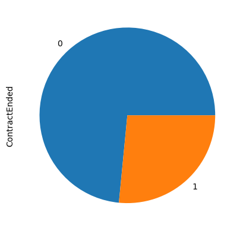

```python
data_contract['ContractEnded'] = (data_contract.EndDate != 'No').astype(int)
data_contract['ContractEnded'].value_counts().plot(kind='pie')
```

```python
data_contract['ContractEnded'].value_counts(normalize=True)
```

```
0    0.73463
1    0.26537
Name: ContractEnded, dtype: float64
```

ContractEnded sería la variable objetivo, se buscará predecir aquellos contratos que terminaron, aquellos cuyo valor sea 1 en esta columna.

Vamos a revisar unas cuantas filas de cada una de las 4 tablas disponibles.

```python
for data in all_datas:
    display(data.head(3))
```

|  | customerID | BeginDate | EndDate | Type | PaperlessBilling | PaymentMethod | MonthlyCharges | TotalCharges | ContractEnded |
| --- | --- | --- | --- | --- | --- | --- | --- | --- | --- |
| 0 | 7590-VHVEG | 2020-01-01 | No | Month-to-month | Yes | Electronic check | 29.85 | 29.85 | 0 |
| 1 | 5575-GNVDE | 2017-04-01 | No | One year | No | Mailed check | 56.95 | 1889.50 | 0 |
| 2 | 3668-QPYBK | 2019-10-01 | 2019-12-01 00:00:00 | Month-to-month | Yes | Mailed check | 53.85 | 108.15 | 1 |

|  | customerID | gender | SeniorCitizen | Partner | Dependents |
| --- | --- | --- | --- | --- | --- |
| 0 | 7590-VHVEG | Female | 0 | Yes | No |
| 1 | 5575-GNVDE | Male | 0 | No | No |
| 2 | 3668-QPYBK | Male | 0 | No | No |

|  | customerID | InternetService | OnlineSecurity | OnlineBackup | DeviceProtection | TechSupport | StreamingTV | StreamingMovies |
| --- | --- | --- | --- | --- | --- | --- | --- | --- |
| 0 | 7590-VHVEG | DSL | No | Yes | No | No | No | No |
| 1 | 5575-GNVDE | DSL | Yes | No | Yes | No | No | No |
| 2 | 3668-QPYBK | DSL | Yes | Yes | No | No | No | No |

|  | customerID | MultipleLines |
| --- | --- | --- |
| 0 | 5575-GNVDE | No |
| 1 | 3668-QPYBK | No |
| 2 | 9237-HQITU | No |

Todas las tablas tiene customerID en común, vamos a unirlas.

```python
merged_data = pd.merge(data_contract, data_personal, on='customerID', how='left')
merged_data = pd.merge(merged_data, data_internet, on='customerID', how='left')
merged_data = pd.merge(merged_data, data_phone, on='customerID', how='left')
merged_data.info()
```

```
<class 'pandas.core.frame.DataFrame'>
Int64Index: 7043 entries, 0 to 7042
Data columns (total 21 columns):
 #   Column            Non-Null Count  Dtype
---  ------            --------------  -----
 0   customerID        7043 non-null   object
 1   BeginDate         7043 non-null   datetime64[ns]
 2   EndDate           7043 non-null   object
 3   Type              7043 non-null   object
 4   PaperlessBilling  7043 non-null   object
 5   PaymentMethod     7043 non-null   object
 6   MonthlyCharges    7043 non-null   float64
 7   TotalCharges      7043 non-null   float64
 8   ContractEnded     7043 non-null   int32
 9   gender            7043 non-null   object
 10  SeniorCitizen     7043 non-null   int64
 11  Partner           7043 non-null   object
 12  Dependents        7043 non-null   object
 13  InternetService   5517 non-null   object
 14  OnlineSecurity    5517 non-null   object
 15  OnlineBackup      5517 non-null   object
 16  DeviceProtection  5517 non-null   object
 17  TechSupport       5517 non-null   object
 18  StreamingTV       5517 non-null   object
 19  StreamingMovies   5517 non-null   object
 20  MultipleLines     6361 non-null   object
dtypes: datetime64[ns](1), float64(2), int32(1), int64(1), object(16)
memory usage: 1.2+ MB
```

### Conclusiones

Se revisarons los datos de los cuatro archivos disponibles. Se hicieron correcciones en 2 columnas, para que concondarán con el tipo de variable esperado. Se revisaron rangos de fechas disponibles y en base a la columna de EndDate, se creó una variable categórica binaria que será nuestra variable objetivo, `ContractEnded`, el cuál representa si el usuario ha dado de baja el servicio o no. Finalmente, se unierons las 4 tablas en una sola, esta contiene datos ausentes provinientes de las tablas de servicio de internet y teléfono.

En la siguiente sección se realizará el preprocesamiento de datos. Una vez se han imputado los datos, se realizará un análisis de la tabla llena.

## Preprocesamiento de datos

### Rellenando datos ausentes

Una parte de los datos ausentes proviene de la tabla de servicios de internet. Se va a asumir entonces, que todos estos valores vacios se deben a que el usuario no tiene contratados servicios de internet. Para estas columnas, se va a reemplazar los NaN por 'No'.

```python
columnas_internet = set(data_internet.columns) - {'customerID'}
columnas_internet
```

```
{'DeviceProtection',
 'InternetService',
 'OnlineBackup',
 'OnlineSecurity',
 'StreamingMovies',
 'StreamingTV',
 'TechSupport'}
```

```python
filled_data = merged_data.copy()
for column in columnas_internet:
    filled_data[column] = filled_data[column].fillna('No')
```

La última columna de MultipleLines, está relacionado al plan de teléfono. Se asumirá que un ausente significa que no tiene contratado servicio de teléfono por lo que se reemplazarán los ausentes por 'No'.

```python
filled_data['MultipleLines'] = filled_data['MultipleLines'].fillna('No')
```

Revisamos un resumen de la tabla para comprobar.

```python
filled_data.info()
```

```
<class 'pandas.core.frame.DataFrame'>
Int64Index: 7043 entries, 0 to 7042
Data columns (total 21 columns):
 #   Column            Non-Null Count  Dtype
---  ------            --------------  -----
 0   customerID        7043 non-null   object
 1   BeginDate         7043 non-null   datetime64[ns]
 2   EndDate           7043 non-null   object
 3   Type              7043 non-null   object
 4   PaperlessBilling  7043 non-null   object
 5   PaymentMethod     7043 non-null   object
 6   MonthlyCharges    7043 non-null   float64
 7   TotalCharges      7043 non-null   float64
 8   ContractEnded     7043 non-null   int32
 9   gender            7043 non-null   object
 10  SeniorCitizen     7043 non-null   int64
 11  Partner           7043 non-null   object
 12  Dependents        7043 non-null   object
 13  InternetService   7043 non-null   object
 14  OnlineSecurity    7043 non-null   object
 15  OnlineBackup      7043 non-null   object
 16  DeviceProtection  7043 non-null   object
 17  TechSupport       7043 non-null   object
 18  StreamingTV       7043 non-null   object
 19  StreamingMovies   7043 non-null   object
 20  MultipleLines     7043 non-null   object
dtypes: datetime64[ns](1), float64(2), int32(1), int64(1), object(16)
memory usage: 1.2+ MB
```

```python
filled_data.head(3)
```

|  | customerID | BeginDate | EndDate | Type | PaperlessBilling | PaymentMethod | MonthlyCharges | TotalCharges | ContractEnded | gender | ... | Partner | Dependents | InternetService | OnlineSecurity | OnlineBackup | DeviceProtection | TechSupport | StreamingTV | StreamingMovies | MultipleLines |
| --- | --- | --- | --- | --- | --- | --- | --- | --- | --- | --- | --- | --- | --- | --- | --- | --- | --- | --- | --- | --- | --- |
| 0 | 7590-VHVEG | 2020-01-01 | No | Month-to-month | Yes | Electronic check | 29.85 | 29.85 | 0 | Female | ... | Yes | No | DSL | No | Yes | No | No | No | No | No |
| 1 | 5575-GNVDE | 2017-04-01 | No | One year | No | Mailed check | 56.95 | 1889.50 | 0 | Male | ... | No | No | DSL | Yes | No | Yes | No | No | No | No |
| 2 | 3668-QPYBK | 2019-10-01 | 2019-12-01 00:00:00 | Month-to-month | Yes | Mailed check | 53.85 | 108.15 | 1 | Male | ... | No | No | DSL | Yes | Yes | No | No | No | No | No |

3 rows × 21 columns

### Número de meses de servicio

Vamos a crear una columna que representa la cantidad de meses que lleva un usuario utilizando el servicio.

```python
fecha_actual = pd.to_datetime('2020-02-01 00:00:00')
fecha_ini =  filled_data['BeginDate']
fecha_fin = pd.to_datetime(filled_data['EndDate'].replace('No', fecha_actual))
filled_data['AccountAge'] = ((fecha_fin.dt.year - fecha_ini.dt.year) * 12) + (fecha_fin.dt.month - fecha_ini.dt.month)
```

### Análisis de datos

Vamos a mostrar diagramas de pastel para aquellas todas las variables categóricas.

```python
non_categorical_vars = ['customerID', 'BeginDate', 'EndDate',
                        'MonthlyCharges', 'TotalCharges', 'AccountAge']
categorical_vars = [col for col in filled_data.columns if col not in non_categorical_vars]
categorical_vars
```

```
['Type',
 'PaperlessBilling',
 'PaymentMethod',
 'ContractEnded',
 'gender',
 'SeniorCitizen',
 'Partner',
 'Dependents',
 'InternetService',
 'OnlineSecurity',
 'OnlineBackup',
 'DeviceProtection',
 'TechSupport',
 'StreamingTV',
 'StreamingMovies',
 'MultipleLines']
```

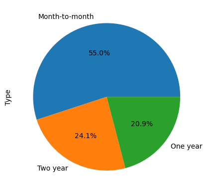

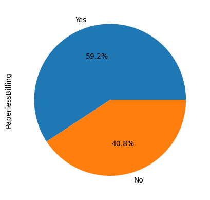

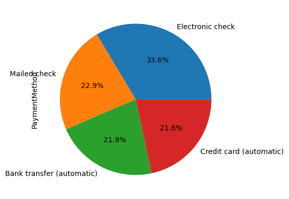

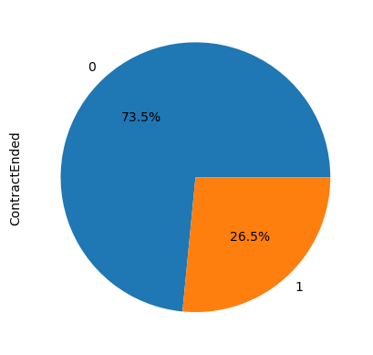

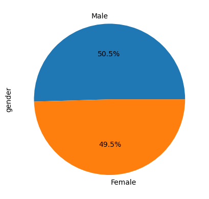

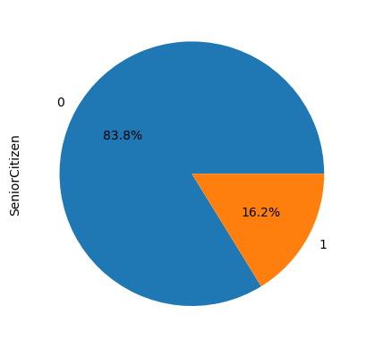

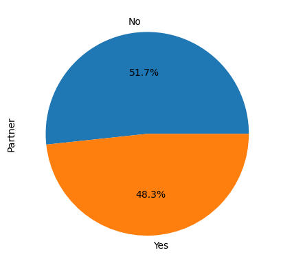

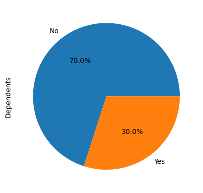

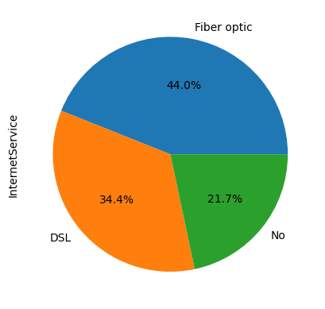

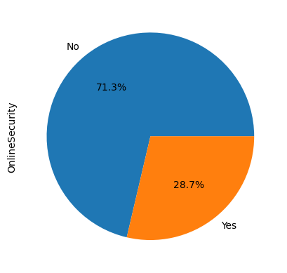

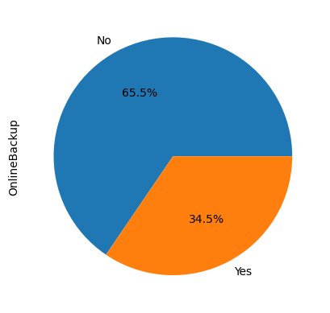

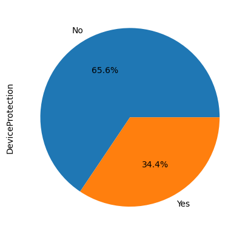

[4 more figures not shown]

```python
for col in categorical_vars:
    plt.figure()
    filled_data[col].value_counts().plot(kind='pie', autopct='%.1f%%')
```

### Conclusiones intermedias

Aunque la mayoría de las variables son binarias, muchas se reducen a dos valores cada uno (Yes/No). Habrá que considera que esto se puede codificar a valores de 1/0 para cumplir con los requerimientos numéricos de varios algoritmos.

### Conversión de datos

Vamos a cambiar el tipo de variables algunas de las características. Varias son categóricas binarias y ya que varios de los modelos igualmente requieren variables númericas, vamos a reemplazar algunas de estas. Primero, comenzaremos cambiando las columnas con valores de Yes/No por 1/0.

```python
yes_no_cols = []
for column in filled_data:
    if set(filled_data[column].unique()) == {'Yes', 'No'}:
        yes_no_cols.append(column)
print(yes_no_cols)
```

```
['PaperlessBilling', 'Partner', 'Dependents', 'OnlineSecurity', 'OnlineBackup', 'DeviceProtection', 'TechSupport', 'StreamingTV', 'StreamingMovies', 'MultipleLines']
```

```python
for column in yes_no_cols:
    filled_data[column] = filled_data[column].replace({'Yes': 1, 'No': 0})
```

Ahora, otra variable con dos clases es la de gender en nuestra tabla. Vamos a simplicar igualmente a unos y ceros igualmente.

```python
filled_data['gender'] = filled_data['gender'].replace({'Male': 1, 'Female': 0})
```

```python
filled_data.head(3)
```

|  | customerID | BeginDate | EndDate | Type | PaperlessBilling | PaymentMethod | MonthlyCharges | TotalCharges | ContractEnded | gender | ... | Dependents | InternetService | OnlineSecurity | OnlineBackup | DeviceProtection | TechSupport | StreamingTV | StreamingMovies | MultipleLines | AccountAge |
| --- | --- | --- | --- | --- | --- | --- | --- | --- | --- | --- | --- | --- | --- | --- | --- | --- | --- | --- | --- | --- | --- |
| 0 | 7590-VHVEG | 2020-01-01 | No | Month-to-month | 1 | Electronic check | 29.85 | 29.85 | 0 | 0 | ... | 0 | DSL | 0 | 1 | 0 | 0 | 0 | 0 | 0 | 1 |
| 1 | 5575-GNVDE | 2017-04-01 | No | One year | 0 | Mailed check | 56.95 | 1889.50 | 0 | 1 | ... | 0 | DSL | 1 | 0 | 1 | 0 | 0 | 0 | 0 | 34 |
| 2 | 3668-QPYBK | 2019-10-01 | 2019-12-01 00:00:00 | Month-to-month | 1 | Mailed check | 53.85 | 108.15 | 1 | 1 | ... | 0 | DSL | 1 | 1 | 0 | 0 | 0 | 0 | 0 | 2 |

3 rows × 22 columns

### Limpiando data

Algunas columnas serán eliminadas, ya sea porque no dan información relevante que sirva para el entrenamiento, como customerID o como las fechas, de las cuales ya se extrajo la característica relevante, los números de meses activos de servicio.

```python
clean_data = filled_data.drop(['customerID', 'BeginDate', 'EndDate'], axis=1)
```

### Sobremuestreo

Hay un desbalance de las clases positivas y negativas de la variable objetivo. Se va a realizar un sobremuestro en la clase positiva con el fin de equilibrar mejor este desbalance.

```python
clean_data['ContractEnded'].value_counts()
```

```
0    5174
1    1869
Name: ContractEnded, dtype: int64
```

```python
SEED = 33333
def upsample(data, target, repeat):
    data_zeros = data[data[target] == 0]
    data_ones = data[data[target] == 1]

    repeat_int = int(repeat)
    repeat_dec = repeat - repeat_int



    data_upsampled = pd.concat([data_zeros] +
                               [data_ones] * repeat_int +
                               [data_ones[0:int(repeat_dec*len(data_ones))]])


    data_upsampled = shuffle(data_upsampled, random_state=SEED)

    return data_upsampled
```

```python
clean_data = upsample(clean_data, 'ContractEnded', 2.75)
clean_data['ContractEnded'].value_counts()
```

```
0    5174
1    5139
Name: ContractEnded, dtype: int64
```

## Conjuntos de datos

Comenzamos separando la variable objetivo y las características a usar.

```python
X = clean_data.drop(['ContractEnded'], axis=1)
y = clean_data['ContractEnded']
```

Vamos a separar los datos en conjuntos de entrenamiento y prueba, usando una proporción de 4:1.

```python
X_train, X_test, y_train, y_test = train_test_split(X, y, test_size=0.2, random_state=SEED)
print(len(X_train), len(y_train))
print(len(X_test), len(y_test))
```

```
8250 8250
2063 2063
```

### One-Hot Encoding

Algunas de las columnas no son númericas y habrán modelos que requerirán que se codifiquen estos datos primero. Vamos a aplicar el One-Hot Encoding (OHE).

```python
categorical_vars = list(set(categorical_vars) - {'ContractEnded'})
categorical_vars
```

```
['PaymentMethod',
 'SeniorCitizen',
 'Partner',
 'DeviceProtection',
 'OnlineSecurity',
 'PaperlessBilling',
 'MultipleLines',
 'StreamingMovies',
 'InternetService',
 'Type',
 'gender',
 'StreamingTV',
 'TechSupport',
 'OnlineBackup',
 'Dependents']
```

```python
var_numericas = list(set(X_train.columns) - set(categorical_vars))
var_numericas
```

```
['MonthlyCharges', 'TotalCharges', 'AccountAge']
```

```python
train_ohe = pd.get_dummies(X_train[categorical_vars], drop_first=True)
test_ohe = pd.get_dummies(X_test[categorical_vars], drop_first=True)
```

```python
X_train_ohe = pd.concat([train_ohe, X_train[var_numericas]], axis=1)
X_test_ohe = pd.concat([test_ohe, X_test[var_numericas]], axis=1)
```

```python
X_train_ohe.info()
```

```
<class 'pandas.core.frame.DataFrame'>
Int64Index: 8250 entries, 3841 to 5521
Data columns (total 22 columns):
 #   Column                                 Non-Null Count  Dtype
---  ------                                 --------------  -----
 0   SeniorCitizen                          8250 non-null   int64
 1   Partner                                8250 non-null   int64
 2   DeviceProtection                       8250 non-null   int64
 3   OnlineSecurity                         8250 non-null   int64
 4   PaperlessBilling                       8250 non-null   int64
 5   MultipleLines                          8250 non-null   int64
 6   StreamingMovies                        8250 non-null   int64
 7   gender                                 8250 non-null   int64
 8   StreamingTV                            8250 non-null   int64
 9   TechSupport                            8250 non-null   int64
 10  OnlineBackup                           8250 non-null   int64
 11  Dependents                             8250 non-null   int64
 12  PaymentMethod_Credit card (automatic)  8250 non-null   uint8
 13  PaymentMethod_Electronic check         8250 non-null   uint8
 14  PaymentMethod_Mailed check             8250 non-null   uint8
 15  InternetService_Fiber optic            8250 non-null   uint8
 16  InternetService_No                     8250 non-null   uint8
 17  Type_One year                          8250 non-null   uint8
 18  Type_Two year                          8250 non-null   uint8
 19  MonthlyCharges                         8250 non-null   float64
 20  TotalCharges                           8250 non-null   float64
 21  AccountAge                             8250 non-null   int64
dtypes: float64(2), int64(13), uint8(7)
memory usage: 1.1 MB
```

## Creación de modelo

### Modelo 0: Prueba de cordura

Vamos a considerar un modelo mantenga la proporción entre los resultados positivos y negativos

```python
y_train.value_counts(normalize=True)
```

```
0    0.506182
1    0.493818
Name: ContractEnded, dtype: float64
```

Asumiremos que la mitad son positivos y la mitad negativos.

```python
cantidad_pos = int(len(y_test)*0.50)
cantidad_neg = len(y_test) - cantidad_pos
y_pred = pd.Series([0] * cantidad_neg + [1] * cantidad_pos)
```

```python
def find_metrics(y_true, y_pred, title = 'Métricas'):
    accuracy = accuracy_score(y_true, y_pred)
    roc_auc = roc_auc_score(y_true, y_pred)
    df = pd.DataFrame(data={'Precision': [accuracy],
                           'ROC-AUC': [roc_auc]})
    df.columns = pd.MultiIndex.from_product([[title], df.columns])
    # df.style.set_caption(title)
    display(df)
    return [accuracy, roc_auc]
```

```python
metrics = {'Precision':{}, 'ROC-AUC':{}}
metrics_tr = {'Precision':{}, 'ROC-AUC':{}}
metrics['Precision'][0], metrics['ROC-AUC'][0] = find_metrics(y_test, y_pred, 'Prueba de Cordura')
```

|  | Prueba de Cordura Precision | Prueba de Cordura ROC-AUC |
| --- | --- | --- |
| 0 | 0.51333 | 0.513352 |

En base a estos valores vamos a determinar si nuestro modelos consiguen ser mejores que el modelo constante.

### Modelo 1: Regresión Logística

Comenzamos con un modelo de regresión logística. Obtendremos las métricas tanto para el conjunto de entrenamiento como el de prueba.

```python
# Definiendo el modelo de regresión
model_1 = LogisticRegression(random_state=SEED, solver='liblinear')

# Entrenando modelo
model_1.fit(X_train_ohe, y_train)

#Obteniendo la predicción
y_train_pred_1 = model_1.predict(X_train_ohe)
y_test_pred_1 = model_1.predict(X_test_ohe)
```

```python
metrics_tr['Precision'][1], metrics_tr['ROC-AUC'][1] = find_metrics(y_train,
                                                              y_train_pred_1,
                                                              'Data de entrenamiento')
metrics['Precision'][1], metrics['ROC-AUC'][1] = find_metrics(y_test,
                                                              y_test_pred_1,
                                                              'Data de prueba')
```

|  | Data de entrenamiento Precision | Data de entrenamiento ROC-AUC |
| --- | --- | --- |
| 0 | 0.765818 | 0.766325 |

|  | Data de prueba Precision | Data de prueba ROC-AUC |
| --- | --- | --- |
| 0 | 0.775085 | 0.774375 |

Con este modelo ya tenemos una mejora con respecto al modelo de cordura. Vamos a ver si podemos mejorarlo, en los siguientes modelos.

### Modelo 2: Bosque Aleatorio

```python
model_2 = RandomForestClassifier(random_state=SEED)
params_rf={"n_estimators": range(100, 200, 10),
            "max_depth": range(5, 15),
            "min_samples_split":range(2,5)
             }
gs_model_2 = GridSearchCV(
    model_2,
    param_grid=params_rf,
    scoring='roc_auc',
    n_jobs=6
)
```

```python
%%time
grid_result_2 = gs_model_2.fit(X_train_ohe, y_train)
```

```
CPU times: total: 8.02 s
Wall time: 4min
```

```python
print("Mejores parámetros encontrados con Bosque Aleatorio: ", grid_result_2.best_params_)
print("ROC-AUC de la validación cruzada: ", grid_result_2.best_score_)
```

```
Mejores parámetros encontrados con Bosque Aleatorio:  {'max_depth': 14, 'min_samples_split': 2, 'n_estimators': 170}
ROC-AUC de la validación cruzada:  0.9372608189842724
```

```python
# Con el modelo entrenado, obtenemos la predicciones
y_train_pred_2 = gs_model_2.predict(X_train_ohe)
y_test_pred_2 = gs_model_2.predict(X_test_ohe)
```

```python
metrics_tr['Precision'][2], metrics_tr['ROC-AUC'][2] = find_metrics(y_train,
                                                                    y_train_pred_2,
                                                                    'Data de entrenamiento')
metrics['Precision'][2], metrics['ROC-AUC'][2] = find_metrics(y_test,
                                                              y_test_pred_2,
                                                              'Data de prueba')
```

|  | Data de entrenamiento Precision | Data de entrenamiento ROC-AUC |
| --- | --- | --- |
| 0 | 0.964 | 0.964419 |

|  | Data de prueba Precision | Data de prueba ROC-AUC |
| --- | --- | --- |
| 0 | 0.898691 | 0.895952 |

Se obtuvo mejor métrica en la data de prueba en este modelo. Comparado con el AUC-ROC del entrenamiento, es menor, lo que indicaría que hay un poco de sobreajuste. La métrica hasta ahora es la mejor, aunque sea más lento que la regresión logistica.

### Modelo 3: LightGBM

```python
model_3 = lgb.LGBMClassifier(random_state=SEED)
params_lGBM={"learning_rate": [0.01, 0.05, 0.1],
             "max_depth": range(5, 19, 2),
             "num_leaves": range(100, 151, 5),
             "min_child_weight": [0.001, 0.01, 0.1]
             }
gs_model_3 = GridSearchCV(
    model_3,
    param_grid=params_lGBM,
    scoring='roc_auc',
    n_jobs=6
)
```

```python
%%time
grid_result_3 = gs_model_3.fit(X_train_ohe, y_train)
```

```
CPU times: total: 26.8 s
Wall time: 3min 50s
```

```python
print("Mejores parámetros encontrados con Bosque Aleatorio: ", grid_result_3.best_params_)
print("ROC-AUC de la validación cruzada: ", grid_result_3.best_score_)
```

```
Mejores parámetros encontrados con Bosque Aleatorio:  {'learning_rate': 0.1, 'max_depth': 17, 'min_child_weight': 0.001, 'num_leaves': 145}
ROC-AUC de la validación cruzada:  0.9145299956395206
```

```python
# Con el modelo entrenado, obtenemos la predicciones
y_train_pred_3 = gs_model_3.predict(X_train_ohe)
y_test_pred_3 = gs_model_3.predict(X_test_ohe)
```

```python
metrics_tr['Precision'][3], metrics_tr['ROC-AUC'][3] = find_metrics(y_train,
                                                                    y_train_pred_3,
                                                                    'Data de entrenamiento')
metrics['Precision'][3], metrics['ROC-AUC'][3] = find_metrics(y_test,
                                                              y_test_pred_3,
                                                              'Data de prueba')
```

|  | Data de entrenamiento Precision | Data de entrenamiento ROC-AUC |
| --- | --- | --- |
| 0 | 0.967636 | 0.967954 |

|  | Data de prueba Precision | Data de prueba ROC-AUC |
| --- | --- | --- |
| 0 | 0.887542 | 0.884934 |

Este modelo obtiene un AUC-ROC mayor que el modelo 1 y 0. Sin embargo, no consiguió que fuera mejor al modelo 2.

### Modelo 4: CatBoost

```python
model_4 = CatBoostClassifier(random_seed=SEED, verbose=False)
params_catBoost={"learning_rate": [0.01, 0.05, 0.1],
             "max_depth": range(3, 11)
             }
gs_model_4 = GridSearchCV(
    model_4,
    param_grid=params_catBoost,
    scoring='roc_auc',
    n_jobs=6
)
```

```python
%%time
grid_result_4 = gs_model_4.fit(X_train_ohe, y_train)
```

```
CPU times: total: 1min 18s
Wall time: 4min 30s
```

```python
print("Mejores parámetros encontrados con catBoost: ", grid_result_4.best_params_)
print("ROC-AUC de la validación cruzada: ", grid_result_4.best_score_)
```

```
Mejores parámetros encontrados con catBoost:  {'learning_rate': 0.1, 'max_depth': 10}
ROC-AUC de la validación cruzada:  0.9401891808737062
```

```python
# Con el modelo entrenado, obtenemos la predicciones
y_train_pred_4 = gs_model_4.predict(X_train_ohe)
y_test_pred_4 = gs_model_4.predict(X_test_ohe)
```

```python
metrics_tr['Precision'][4], metrics_tr['ROC-AUC'][4] = find_metrics(y_train,
                                                                    y_train_pred_4,
                                                                    'Data de entrenamiento')
metrics['Precision'][4], metrics['ROC-AUC'][4] = find_metrics(y_test,
                                                              y_test_pred_4,
                                                              'Data de prueba')
```

|  | Data de entrenamiento Precision | Data de entrenamiento ROC-AUC |
| --- | --- | --- |
| 0 | 0.997333 | 0.997357 |

|  | Data de prueba Precision | Data de prueba ROC-AUC |
| --- | --- | --- |
| 0 | 0.905477 | 0.902935 |

Tiene igual un sobreajuste con respecto a la data de entrenamiento. Aun así, eL AUC-ROC en este caso es el mejor de todos los demás modelos.

### Resumen de los modelos

Vamos a mostra un resumen de los datos de las métricas usadas.

```python
# Métricas de con el conjunto de entrenamiento
resumen_modelos_tr = pd.DataFrame(data=metrics_tr).sort_index()
resumen_modelos_tr
```

|  | Precision | ROC-AUC |
| --- | --- | --- |
| 1 | 0.765818 | 0.766325 |
| 2 | 0.964000 | 0.964419 |
| 3 | 0.967636 | 0.967954 |
| 4 | 0.997333 | 0.997357 |

```python
# Métricas de con el conjunto de prueba
resumen_modelos = pd.DataFrame(data=metrics).sort_index()
resumen_modelos
```

|  | Precision | ROC-AUC |
| --- | --- | --- |
| 0 | 0.513330 | 0.513352 |
| 1 | 0.775085 | 0.774375 |
| 2 | 0.898691 | 0.895952 |
| 3 | 0.887542 | 0.884934 |
| 4 | 0.905477 | 0.902935 |

```python
# Diferencia absoluta entre los datos de entrenamiento y prueba
resumen_modelos_tr-resumen_modelos
```

|  | Precision | ROC-AUC |
| --- | --- | --- |
| 0 | NaN | NaN |
| 1 | -0.009267 | -0.008050 |
| 2 | 0.065309 | 0.068466 |
| 3 | 0.080094 | 0.083020 |
| 4 | 0.091856 | 0.094422 |

Todos los modelos creados superan el valor de la prueba de cordura. Los dos mejores modelos son el 2 y 4, el modelo de Bosque Aleatorio y CatBoost.

### Conclusiones

Los modelos 2, 3 y 4 mostraron que están sobreajustados. Hay una diferencia de aproximadamente 0.06-0.09 entre las métricas de la dataset de prueba y entrenamiento. Aun así, sus predicciones superan al de la prueba de cordura, por lo que servirían como modelos de predicción. El modelo 1 fue el único que no tuvo sobreajuste según las métricas resultantes, sin embargo, también tiene el menor valor de AUC-ROC, por lo que no sería el modelo idea a elegir.

Nos interesa el valor de la métrica, pero también nos interesa que el modelo sea confiable para predecir. Podríamos decir que el modelo 4, CatBoost, sería el elegido, ya que fue el que resultó con el mejor ROC-AUC. Sin embargo, también tiene la mayor diferencia entre los resultados del dataset de prueba vs el entrenamiento. Indicaría que es el modelo con mayor problema de sobreajuste de los probados.

Dado esto, la elección final sería con el modelo 2, que usó bosque aleatorio, ya que dió un ROC-AUC de 0.896, el segundo más alto, teniendo también de los menores sobreajustes, lo que nos da más confianza de que el modelo sirva para predecir datos nuevos.

## Conclusiones

Se comenzó con 4 archivos con información de los contratos y los clientes, los cuales fueron unidos a través del CustomerID. Se realizaron cambios a los tipos de variables de un par de columnas antes de continuar con la unión. Se creó la variables ContractEnded la cual sería nuestra variablle objetivo.

Luego se realizó el preprocesamiento, primero se rellenaron los datos ausentes. Como estos valores ausentes provienieron de las tablas de los planes de internet y teléfono, se asumió que esto implicaba que no estába usando dicho servicio un usuario en específico. Por tanto, se rellenó con 'No' estas variables para indicar que el usuario no tiene esos servicios activos. Luego se calculó una variable extra que contendría el número de meses que ha tenido un usuario el contrato.

La mayoría de datos eran categóricos binarios, por lo que fueron reemplazados por valores de 1/0. Luego se quitaron las columnas que no serían necesarias para el entrenamiento. Dado que la relación entre la clase positiva y negativa de la función objetivo estaba desbalanceada, se realizó sobremuestreo, para equipar mejor la proporción de ambos.

Varios modelos requieren solo usar datos numéricos por lo que se aplicó One-Hot Encoding para tratar los valores categóricos restantes.

Además de la prueba de cordura, se crearon 4 modelos, uno que aplicó regresión logística, otro de bosque aleatorio, uno con LightGBM y otro de CatBoost. Los 4 superaron la prueba de cordura y los mejores valors de AUC-ROC se obtuvieron del modelo 2 y 4. Aunque el modelo 4 tenía la mejor métrica, también presenta el mayor sobreajuste. Por tanto, se eligió el modelo 2, que tiene aun así el segundo mejor AUC-ROC pero tiene menor sobreajuste, dando más confianza que este modelo pueda predecir mejor en casos de datos nuevos.